Skip to main content

# Publication figure report

Author

Affiliation

none

manual

**Important**

A manual command generated this report without an LLM model. No separate human scientific review is part of this fixed recipe. The report records the selected recipe and does not claim a new statistical method.

## Figure

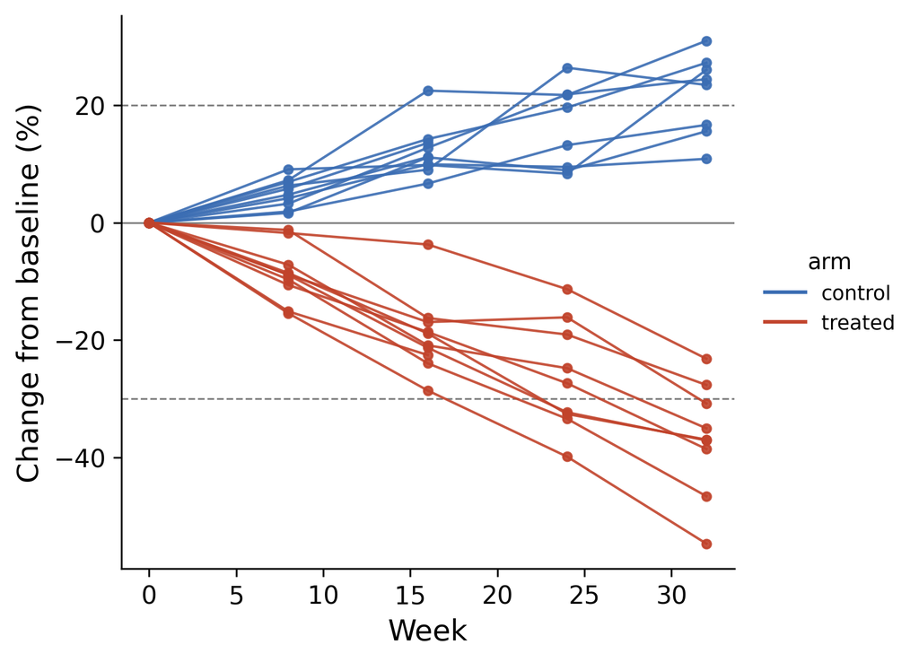

Publication figure

## Statistical results

| patient | baseline | visits | best_change_pct | worst_change_pct | last_change_pct | category_from_change | group |
| --- | --- | --- | --- | --- | --- | --- | --- |
| PT-19 | 47.9 | 5 | -54.6972860125261 | -15.448851774530269 | -54.6972860125261 | partial response | treated |
| PT-14 | 82.6 | 5 | -46.61016949152542 | -9.685230024213075 | -46.61016949152542 | partial response | treated |
| PT-16 | 68.7 | 5 | -38.57350800582241 | -10.625909752547313 | -38.57350800582241 | partial response | treated |
| PT-13 | 85.4 | 5 | -37.11943793911007 | -8.899297423887598 | -37.11943793911007 | partial response | treated |
| PT-17 | 64.1 | 5 | -36.973478939157566 | -8.58034321372854 | -36.973478939157566 | partial response | treated |
| PT-11 | 48.8 | 5 | -35.040983606557376 | -7.172131147540984 | -35.040983606557376 | partial response | treated |
| PT-12 | 62.0 | 5 | -30.806451612903228 | -8.870967741935484 | -30.806451612903228 | partial response | treated |
| PT-20 | 64.0 | 5 | -27.656250000000004 | -1.2499999999999956 | -27.656250000000004 | stable disease | treated |
| PT-18 | 56.5 | 5 | -23.185840707964605 | -1.7699115044247788 | -23.185840707964605 | stable disease | treated |
| PT-15 | 76.7 | 3 | -22.555410691003917 | -15.123859191655812 | -22.555410691003917 | stable disease | treated |
| PT-01 | 53.9 | 5 | 1.6697588126159528 | 15.584415584415583 | 15.584415584415583 | stable disease | control |
| PT-09 | 84.0 | 5 | 1.904761904761898 | 16.666666666666668 | 16.666666666666668 | stable disease | control |
| PT-10 | 46.2 | 5 | 3.2467532467532467 | 24.45887445887445 | 24.45887445887445 | progressive disease | control |
| PT-05 | 43.2 | 5 | 4.16666666666666 | 10.879629629629619 | 10.879629629629619 | stable disease | control |
| PT-08 | 54.5 | 3 | 4.770642201834865 | 11.192660550458717 | 11.192660550458717 | stable disease | control |
| PT-03 | 65.5 | 3 | 5.801526717557247 | 13.587786259541993 | 13.587786259541993 | stable disease | control |
| PT-07 | 44.3 | 5 | 6.320541760722358 | 26.41083521444696 | 23.476297968397304 | progressive disease | control |
| PT-06 | 87.7 | 5 | 6.955530216647656 | 27.25199543899657 | 27.25199543899657 | progressive disease | control |
| PT-02 | 40.0 | 5 | 7.249999999999997 | 30.999999999999993 | 30.999999999999993 | progressive disease | control |
| PT-04 | 40.7 | 5 | 8.35380835380835 | 26.044226044226033 | 26.044226044226033 | progressive disease | control |

## Methods

Target_lesion_mm was expressed as a percentage change from each patient’s own baseline, which is the first measurement in time, and drawn as one line per patient (n = 20 patients, 94 measurements). Dashed reference lines mark +20% and -30%, the RECIST 1.1 thresholds for progressive disease and for a partial response. On the change from baseline alone, 7 patient(s) reached a partial response, 8 were stable and 5 reached progressive disease. That categorisation reads the target lesion change from baseline only. A full RECIST 1.1 assessment also reads the nadir, the non-target lesions and any new lesion. The figure is descriptive, so no statistical test is applied. Drawn in Python 3.10.12 with matplotlib 3.10.9.

## Plot configuration

The complete plot configuration is in `plot_config.yaml`.

## Provenance

| field | value |
| --- | --- |
| repository | pubready |
| repository_version | 4.0.0 |
| git_commit | 567ce8900bdb5db88369d131c8d787b042b3af57 |
| git_dirty | FALSE |
| llm_provider | none |
| llm_model | none |
| agent_harness | manual |
| agent_harness_version | not_recorded |
| container_image | localhost/pubready:4.0.0 |
| container_digest | sha256:0f57027a3fbca5ec9d41d74ca91226fbdf45d94b1a85f271637d12733db5d483 |
| input | {“file”: “input_target_lesion_mm.csv”, “md5”: “d3ceaf1a40e01ce2639a76cda972d28e”, “sha256”: “97ca47b3a60d61efa8b26f77be4c7169722126bb8198f60c17acef4d6f04d23c”} |
| command | figkit plot –recipe spider_response |
| analysis_options | {“engine”: “python”, “recipe”: “spider_response”, “data”: {“file”: “spider_response.csv”, “x”: “week”, “y”: “target_lesion_mm”, “fill”: null, “facet”: null, “time”: null, “event”: null, “annotation”: … |
| random_seeds | not_applicable |
| session_record | session_info.txt |
| created_utc | 2026-07-18T00:00:00Z |
| review_state | not_applicable |
| reviewer | none |
| quarto_version | 1.11.4 |

The report source reads only files in this bundle.